# Overview

Dataset info

| Number of variables | 22 |
| --- | --- |
| Number of observations | 193926 |
| Missing cells | 1030640 (24.2%) |
| Duplicate rows | 0 (0.0%) |
| Total size in memory | 32.5 MiB |
| Average record size in memory | 176.0 B |

Variables types

| Numeric | 5 |
| --- | --- |
| Categorical | 12 |
| Boolean | 0 |
| Date | 0 |
| URL | 0 |
| Text (Unique) | 0 |
| Rejected | 5 |
| Unsupported | 0 |

Warnings

| `Address` has a high cardinality: 18021 distinct values | Warning |
| --- | --- |
| `AKA_Name` has a high cardinality: 26165 distinct values | Warning |
| `AKA_Name` has 2448 (1.3%) missing values | Missing |
| `Census_Tracts` has constant value "nan" | Rejected |
| `City` has a high cardinality: 72 distinct values | Warning |
| `Community_Areas` has constant value "nan" | Rejected |
| `DBA_Name` has a high cardinality: 27419 distinct values | Warning |
| `Facility_Type` has a high cardinality: 488 distinct values | Warning |
| `Facility_Type` has 4779 (2.5%) missing values | Missing |
| `Historical_Wards_2003-2015` has constant value "nan" | Rejected |
| `Inspection_Date` has a high cardinality: 2479 distinct values | Warning |
| `Inspection_Type` has a high cardinality: 109 distinct values | Warning |
| `Location` has a high cardinality: 16790 distinct values | Warning |
| `Violations` has a high cardinality: 141671 distinct values | Warning |
| `Violations` has 51432 (26.5%) missing values | Missing |
| `Wards` has constant value "nan" | Rejected |
| `Zip` is highly skewed (γ1 = -370.4959341) | Skewed |
| `Zip_Codes` has constant value "nan" | Rejected |

# Variables

Address  
Categorical

| Distinct count | 18021 |
| --- | --- |
| Unique (%) | 9.3% |
| Missing (%) | 0.0% |
| Missing (n) | 0 |

| 11601 W TOUHY AVE | 2545 |
| --- | --- |
| 5700 S CICERO AVE | 520 |
| 500 W MADISON ST | 432 |
| Other values (18018) | 190429 |

Toggle details

**Common values**

| Value | Count | Frequency (%) |  |
| --- | --- | --- | --- |
| 11601 W TOUHY AVE | 2545 | 1.3% |  |
| 5700 S CICERO AVE | 520 | 0.3% |  |
| 500 W MADISON ST | 432 | 0.2% |  |
| 324 N LEAVITT ST | 386 | 0.2% |  |
| 2300 S THROOP ST | 362 | 0.2% |  |
| 131 N CLINTON ST | 328 | 0.2% |  |
| 100 W RANDOLPH ST | 308 | 0.2% |  |
| 600 E GRAND AVE | 259 | 0.1% |  |
| 7601 S CICERO AVE | 258 | 0.1% |  |
| 222 W MERCHANDISE MART PLZ | 252 | 0.1% |  |
| Other values (18011) | 188276 | 97.1% |  |

**Composition**

| Max length | 40 |
| --- | --- |
| Mean length | 18.57581758 |
| Min length | 1 |
| Contains chars | True |
| Contains digits | True |
| Contains spaces | True |
| Contains non-words | True |

AKA_Name  
Categorical

| Distinct count | 26165 |
| --- | --- |
| Unique (%) | 13.5% |
| Missing (%) | 1.3% |
| Missing (n) | 2448 |

| SUBWAY | 3244 |
| --- | --- |
| DUNKIN DONUTS | 1377 |
| MCDONALD'S | 764 |
| Other values (26161) | 186093 |
| (Missing) | 2448 |

Toggle details

**Common values**

| Value | Count | Frequency (%) |  |
| --- | --- | --- | --- |
| SUBWAY | 3244 | 1.7% |  |
| DUNKIN DONUTS | 1377 | 0.7% |  |
| MCDONALD'S | 764 | 0.4% |  |
| 7-ELEVEN | 744 | 0.4% |  |
| BURGER KING | 372 | 0.2% |  |
| MCDONALDS | 342 | 0.2% |  |
| CHIPOTLE MEXICAN GRILL | 318 | 0.2% |  |
| DUNKIN DONUTS/BASKIN ROBBINS | 317 | 0.2% |  |
| STARBUCKS COFFEE | 294 | 0.2% |  |
| WENDY'S | 293 | 0.2% |  |
| Other values (26154) | 183413 | 94.6% |  |
| (Missing) | 2448 | 1.3% |  |

**Composition**

| Max length | 79 |
| --- | --- |
| Mean length | 17.76302817 |
| Min length | 1 |
| Contains chars | True |
| Contains digits | True |
| Contains spaces | True |
| Contains non-words | True |

Census_Tracts  
Constant

*This variable is constant and should be ignored for analysis*

| Constant value | nan |
| --- | --- |

City  
Categorical

| Distinct count | 72 |
| --- | --- |
| Unique (%) | < 0.1% |
| Missing (%) | 0.1% |
| Missing (n) | 136 |

| CHICAGO | 193090 |
| --- | --- |
| Chicago | 320 |
| chicago | 97 |
| Other values (68) | 283 |
| (Missing) | 136 |

Toggle details

**Common values**

| Value | Count | Frequency (%) |  |
| --- | --- | --- | --- |
| CHICAGO | 193090 | 99.6% |  |
| Chicago | 320 | 0.2% |  |
| chicago | 97 | 0.1% |  |
| CCHICAGO | 46 | < 0.1% |  |
| SCHAUMBURG | 24 | < 0.1% |  |
| MAYWOOD | 15 | < 0.1% |  |
| ELK GROVE VILLAGE | 13 | < 0.1% |  |
| CHicago | 12 | < 0.1% |  |
| EVANSTON | 11 | < 0.1% |  |
| CHESTNUT STREET | 11 | < 0.1% |  |
| Other values (61) | 151 | 0.1% |  |
| (Missing) | 136 | 0.1% |  |

**Composition**

| Max length | 20 |
| --- | --- |
| Mean length | 7.000964285 |
| Min length | 3 |
| Contains chars | True |
| Contains digits | True |
| Contains spaces | True |
| Contains non-words | True |

Community_Areas  
Constant

*This variable is constant and should be ignored for analysis*

| Constant value | nan |
| --- | --- |

DBA_Name  
Categorical

| Distinct count | 27419 |
| --- | --- |
| Unique (%) | 14.1% |
| Missing (%) | 0.0% |
| Missing (n) | 0 |

| SUBWAY | 2667 |
| --- | --- |
| DUNKIN DONUTS | 1380 |
| MCDONALD'S | 570 |
| Other values (27416) | 189309 |

Toggle details

**Common values**

| Value | Count | Frequency (%) |  |
| --- | --- | --- | --- |
| SUBWAY | 2667 | 1.4% |  |
| DUNKIN DONUTS | 1380 | 0.7% |  |
| MCDONALD'S | 570 | 0.3% |  |
| 7-ELEVEN | 433 | 0.2% |  |
| MCDONALDS | 329 | 0.2% |  |
| CHIPOTLE MEXICAN GRILL | 307 | 0.2% |  |
| POTBELLY SANDWICH WORKS LLC | 273 | 0.1% |  |
| CORNER BAKERY CAFE | 239 | 0.1% |  |
| POTBELLY SANDWICH WORKS | 237 | 0.1% |  |
| DUNKIN DONUTS/BASKIN ROBBINS | 225 | 0.1% |  |
| Other values (27409) | 187266 | 96.6% |  |

**Composition**

| Max length | 79 |
| --- | --- |
| Mean length | 18.65384219 |
| Min length | 2 |
| Contains chars | True |
| Contains digits | True |
| Contains spaces | True |
| Contains non-words | True |

Facility_Type  
Categorical

| Distinct count | 488 |
| --- | --- |
| Unique (%) | 0.3% |
| Missing (%) | 2.5% |
| Missing (n) | 4779 |

| Restaurant | 129258 |
| --- | --- |
| Grocery Store | 24768 |
| School | 12025 |
| Other values (484) | 23096 |
| (Missing) | 4779 |

Toggle details

**Common values**

| Value | Count | Frequency (%) |  |
| --- | --- | --- | --- |
| Restaurant | 129258 | 66.7% |  |
| Grocery Store | 24768 | 12.8% |  |
| School | 12025 | 6.2% |  |
| Children's Services Facility | 2933 | 1.5% |  |
| Bakery | 2832 | 1.5% |  |
| Daycare (2 - 6 Years) | 2682 | 1.4% |  |
| Daycare Above and Under 2 Years | 2320 | 1.2% |  |
| Long Term Care | 1326 | 0.7% |  |
| Catering | 1178 | 0.6% |  |
| Mobile Food Dispenser | 867 | 0.4% |  |
| Other values (477) | 8958 | 4.6% |  |
| (Missing) | 4779 | 2.5% |  |

**Composition**

| Max length | 47 |
| --- | --- |
| Mean length | 10.83090973 |
| Min length | 3 |
| Contains chars | True |
| Contains digits | True |
| Contains spaces | True |
| Contains non-words | True |

Historical_Wards_2003-2015  
Constant

*This variable is constant and should be ignored for analysis*

| Constant value | nan |
| --- | --- |

Inspection_Date  
Categorical

| Distinct count | 2479 |
| --- | --- |
| Unique (%) | 1.3% |
| Missing (%) | 0.0% |
| Missing (n) | 0 |

| 11/14/2013 | 185 |
| --- | --- |
| 09/13/2016 | 149 |
| 11/29/2016 | 145 |
| Other values (2476) | 193447 |

Toggle details

**Common values**

| Value | Count | Frequency (%) |  |
| --- | --- | --- | --- |
| 11/14/2013 | 185 | 0.1% |  |
| 09/13/2016 | 149 | 0.1% |  |
| 11/29/2016 | 145 | 0.1% |  |
| 12/16/2014 | 143 | 0.1% |  |
| 12/03/2014 | 142 | 0.1% |  |
| 10/01/2013 | 142 | 0.1% |  |
| 09/29/2016 | 140 | 0.1% |  |
| 12/02/2014 | 140 | 0.1% |  |
| 09/26/2016 | 138 | 0.1% |  |
| 09/08/2016 | 137 | 0.1% |  |
| Other values (2469) | 192465 | 99.2% |  |

**Composition**

| Max length | 10 |
| --- | --- |
| Mean length | 10 |
| Min length | 10 |
| Contains chars | False |
| Contains digits | True |
| Contains spaces | False |
| Contains non-words | True |

Inspection_ID  
Numeric

| Distinct count | 193926 |
| --- | --- |
| Unique (%) | 100.0% |
| Missing (%) | 0.0% |
| Missing (n) | 0 |
| Infinite (%) | 0.0% |
| Infinite (n) | 0 |

| Mean | 1436316.451 |
| --- | --- |
| Minimum | 44247 |
| Maximum | 2315401 |
| Zeros (%) | 0.0% |

[figure not shown]

Toggle details

**Statistics**

Quantile statistics

| Minimum | 44247 |
| --- | --- |
| 5-th percentile | 250487.25 |
| Q1 | 1146397.25 |
| Median | 1482761.5 |
| Q3 | 1983111.75 |
| 95-th percentile | 2279484.75 |
| Maximum | 2315401 |
| Range | 2271154 |
| Interquartile range | 836714.5 |

Descriptive statistics

| Standard deviation | 631165.4548 |
| --- | --- |
| Coef of variation | 0.4394334232 |
| Kurtosis | -0.7400786003 |
| Mean | 1436316.451 |
| MAD | 508507.6235 |
| Skewness | -0.5108638306 |
| Sum | 2.785391041e+11 |
| Variance | 3.983698314e+11 |
| Memory size | 1.5 MiB |

**Histogram**

[figure not shown]

**Histogram with fixed size bins** (bins=50)

[figure not shown]

**Histogram with variable size bins** (bins=[ 44247. 44261.5 48212.5 48229.5 52234.5 ... 2311211.5 2312787.5 2313203.5 2315212. 2315401. ], ["bayesian blocks"](https://ui.adsabs.harvard.edu/abs/2013ApJ...764..167S/abstract) binning strategy used)

**Common values**

| Value | Count | Frequency (%) |  |
| --- | --- | --- | --- |
| 2099199 | 1 | < 0.1% |  |
| 1447272 | 1 | < 0.1% |  |
| 1230194 | 1 | < 0.1% |  |
| 80280 | 1 | < 0.1% |  |
| 2282864 | 1 | < 0.1% |  |
| 1453423 | 1 | < 0.1% |  |
| 1975662 | 1 | < 0.1% |  |
| 2243949 | 1 | < 0.1% |  |
| 1445227 | 1 | < 0.1% |  |
| 2229610 | 1 | < 0.1% |  |
| Other values (193916) | 193916 | > 99.9% |  |

**Extreme values**

Minimum 5 values

| Value | Count | Frequency (%) |  |
| --- | --- | --- | --- |
| 44247 | 1 | < 0.1% |  |
| 44248 | 1 | < 0.1% |  |
| 44249 | 1 | < 0.1% |  |
| 44250 | 1 | < 0.1% |  |
| 44251 | 1 | < 0.1% |  |

Maximum 5 values

| Value | Count | Frequency (%) |  |
| --- | --- | --- | --- |
| 2315401 | 1 | < 0.1% |  |
| 2315379 | 1 | < 0.1% |  |
| 2315363 | 1 | < 0.1% |  |
| 2315362 | 1 | < 0.1% |  |
| 2315353 | 1 | < 0.1% |  |

Inspection_Type  
Categorical

| Distinct count | 109 |
| --- | --- |
| Unique (%) | 0.1% |
| Missing (%) | < 0.1% |
| Missing (n) | 1 |

| Canvass | 102498 |
| --- | --- |
| License | 25600 |
| Canvass Re-Inspection | 20300 |
| Other values (105) | 45527 |

Toggle details

**Common values**

| Value | Count | Frequency (%) |  |
| --- | --- | --- | --- |
| Canvass | 102498 | 52.9% |  |
| License | 25600 | 13.2% |  |
| Canvass Re-Inspection | 20300 | 10.5% |  |
| Complaint | 18048 | 9.3% |  |
| License Re-Inspection | 8887 | 4.6% |  |
| Complaint Re-Inspection | 7432 | 3.8% |  |
| Short Form Complaint | 6699 | 3.5% |  |
| Suspected Food Poisoning | 849 | 0.4% |  |
| Consultation | 671 | 0.3% |  |
| License-Task Force | 605 | 0.3% |  |
| Other values (98) | 2336 | 1.2% |  |

**Composition**

| Max length | 41 |
| --- | --- |
| Mean length | 10.61234182 |
| Min length | 3 |
| Contains chars | True |
| Contains digits | True |
| Contains spaces | True |
| Contains non-words | True |

Latitude  
Numeric

| Distinct count | 16782 |
| --- | --- |
| Unique (%) | 8.7% |
| Missing (%) | 0.4% |
| Missing (n) | 679 |
| Infinite (%) | 0.0% |
| Infinite (n) | 0 |

| Mean | 41.88130949 |
| --- | --- |
| Minimum | 41.64467013 |
| Maximum | 42.02106425 |
| Zeros (%) | 0.0% |

[figure not shown]

Toggle details

**Statistics**

Quantile statistics

| Minimum | 41.64467013 |
| --- | --- |
| 5-th percentile | 41.72839361 |
| Q1 | 41.83551771 |
| Median | 41.89198012 |
| Q3 | 41.93982046 |
| 95-th percentile | 41.99759419 |
| Maximum | 42.02106425 |
| Range | 0.37639412 |
| Interquartile range | 0.10430275 |

Descriptive statistics

| Standard deviation | 0.08078307347 |
| --- | --- |
| Coef of variation | 0.001928857394 |
| Kurtosis | -0.3321448046 |
| Mean | 41.88130949 |
| MAD | 0.0639682519 |
| Skewness | -0.5905573807 |
| Sum | 8093437.415 |
| Variance | 0.006525904959 |
| Memory size | 1.5 MiB |

**Histogram**

[figure not shown]

**Histogram with fixed size bins** (bins=50)

**Common values**

| Value | Count | Frequency (%) |  |
| --- | --- | --- | --- |
| 42.0085364 | 2556 | 1.3% |  |
| 41.78932932 | 520 | 0.3% |  |
| 41.88418751 | 471 | 0.2% |  |
| 41.88199434 | 452 | 0.2% |  |
| 41.88743405 | 444 | 0.2% |  |
| 41.85045102 | 369 | 0.2% |  |
| 41.88458627 | 319 | 0.2% |  |
| 41.88807428 | 274 | 0.1% |  |
| 41.75466012 | 263 | 0.1% |  |
| 41.89209414 | 259 | 0.1% |  |
| Other values (16771) | 187320 | 96.6% |  |
| (Missing) | 679 | 0.4% |  |

**Extreme values**

Minimum 5 values

| Value | Count | Frequency (%) |  |
| --- | --- | --- | --- |
| 41.64467013 | 11 | < 0.1% |  |
| 41.64566748 | 4 | < 0.1% |  |
| 41.64637082 | 7 | < 0.1% |  |
| 41.64655405 | 2 | < 0.1% |  |
| 41.64818878 | 9 | < 0.1% |  |

Maximum 5 values

| Value | Count | Frequency (%) |  |
| --- | --- | --- | --- |
| 42.02106425 | 17 | < 0.1% |  |
| 42.02086075 | 12 | < 0.1% |  |
| 42.02080848 | 13 | < 0.1% |  |
| 42.02075289 | 7 | < 0.1% |  |
| 42.02039924 | 1 | < 0.1% |  |

License_#  
Numeric

| Distinct count | 37139 |
| --- | --- |
| Unique (%) | 19.2% |
| Missing (%) | < 0.1% |
| Missing (n) | 17 |
| Infinite (%) | 0.0% |
| Infinite (n) | 0 |

| Mean | 1594687.165 |
| --- | --- |
| Minimum | 0 |
| Maximum | 9999999 |
| Zeros (%) | 0.3% |

[figure not shown]

Toggle details

**Statistics**

Quantile statistics

| Minimum | 0 |
| --- | --- |
| 5-th percentile | 15512 |
| Q1 | 1222833 |
| Median | 1975019 |
| Q3 | 2232347 |
| 95-th percentile | 2535609 |
| Maximum | 9999999 |
| Range | 9999999 |
| Interquartile range | 1009514 |

Descriptive statistics

| Standard deviation | 895407.8338 |
| --- | --- |
| Coef of variation | 0.5614943503 |
| Kurtosis | -0.5822880985 |
| Mean | 1594687.165 |
| MAD | 743201.6268 |
| Skewness | -0.8666491129 |
| Sum | 3.092241935e+11 |
| Variance | 8.017551888e+11 |
| Memory size | 1.5 MiB |

**Histogram**

[figure not shown]

**Histogram with fixed size bins** (bins=50)

**Common values**

| Value | Count | Frequency (%) |  |
| --- | --- | --- | --- |
| 0 | 512 | 0.3% |  |
| 1354323 | 198 | 0.1% |  |
| 14616 | 175 | 0.1% |  |
| 1574001 | 83 | < 0.1% |  |
| 1974745 | 59 | < 0.1% |  |
| 1142451 | 48 | < 0.1% |  |
| 1884255 | 48 | < 0.1% |  |
| 1490035 | 46 | < 0.1% |  |
| 2083833 | 46 | < 0.1% |  |
| 1596210 | 45 | < 0.1% |  |
| Other values (37128) | 192649 | 99.3% |  |

**Extreme values**

Minimum 5 values

| Value | Count | Frequency (%) |  |
| --- | --- | --- | --- |
| 0 | 512 | 0.3% |  |
| 1 | 1 | < 0.1% |  |
| 2 | 15 | < 0.1% |  |
| 9 | 14 | < 0.1% |  |
| 40 | 18 | < 0.1% |  |

Maximum 5 values

| Value | Count | Frequency (%) |  |
| --- | --- | --- | --- |
| 9999999 | 1 | < 0.1% |  |
| 8700606 | 3 | < 0.1% |  |
| 5852857 | 1 | < 0.1% |  |
| 3846211 | 1 | < 0.1% |  |
| 3846027 | 1 | < 0.1% |  |

Location  
Categorical

| Distinct count | 16790 |
| --- | --- |
| Unique (%) | 8.7% |
| Missing (%) | 0.4% |
| Missing (n) | 679 |

| (-87.91442843927047, 42.008536400868735) | 2556 |
| --- | --- |
| (-87.74164564419637, 41.789329323265385) | 520 |
| (-87.64111966683218, 41.884187507127805) | 471 |
| Other values (16786) | 189700 |
| (Missing) | 679 |

Toggle details

**Common values**

| Value | Count | Frequency (%) |  |
| --- | --- | --- | --- |
| (-87.91442843927047, 42.008536400868735) | 2556 | 1.3% |  |
| (-87.74164564419637, 41.789329323265385) | 520 | 0.3% |  |
| (-87.64111966683218, 41.884187507127805) | 471 | 0.2% |  |
| (-87.6397586848809, 41.88199433820508) | 452 | 0.2% |  |
| (-87.68184949426895, 41.88743405025222) | 444 | 0.2% |  |
| (-87.65879785567869, 41.85045102427) | 369 | 0.2% |  |
| (-87.63101044588599, 41.88458626715456) | 319 | 0.2% |  |
| (-87.63495520292739, 41.8880742810662) | 274 | 0.1% |  |
| (-87.74138475860521, 41.75466012439374) | 263 | 0.1% |  |
| (-87.61156988394656, 41.892094136861786) | 259 | 0.1% |  |
| Other values (16779) | 187320 | 96.6% |  |
| (Missing) | 679 | 0.4% |  |

**Composition**

| Max length | 40 |
| --- | --- |
| Mean length | 38.94987263 |
| Min length | 3 |
| Contains chars | True |
| Contains digits | True |
| Contains spaces | True |
| Contains non-words | True |

Longitude  
Numeric

| Distinct count | 16782 |
| --- | --- |
| Unique (%) | 8.7% |
| Missing (%) | 0.4% |
| Missing (n) | 679 |
| Infinite (%) | 0.0% |
| Infinite (n) | 0 |

| Mean | -87.67684712 |
| --- | --- |
| Minimum | -87.91442844 |
| Maximum | -87.52509414 |
| Zeros (%) | 0.0% |

[figure not shown]

Toggle details

**Statistics**

Quantile statistics

| Minimum | -87.91442844 |
| --- | --- |
| 5-th percentile | -87.77842839 |
| Q1 | -87.70779462 |
| Median | -87.66684643 |
| Q3 | -87.6349552 |
| 95-th percentile | -87.60178732 |
| Maximum | -87.52509414 |
| Range | 0.3893343 |
| Interquartile range | 0.07283942 |

Descriptive statistics

| Standard deviation | 0.05887314444 |
| --- | --- |
| Coef of variation | -0.000671478804 |
| Kurtosis | 2.458170156 |
| Mean | -87.67684712 |
| MAD | 0.04454343292 |
| Skewness | -1.063931443 |
| Sum | -16943287.68 |
| Variance | 0.003466047136 |
| Memory size | 1.5 MiB |

**Histogram**

[figure not shown]

**Histogram with fixed size bins** (bins=50)

**Common values**

| Value | Count | Frequency (%) |  |
| --- | --- | --- | --- |
| -87.91442844 | 2556 | 1.3% |  |
| -87.74164564 | 520 | 0.3% |  |
| -87.64111967 | 471 | 0.2% |  |
| -87.63975868 | 452 | 0.2% |  |
| -87.68184949 | 444 | 0.2% |  |
| -87.65879786 | 369 | 0.2% |  |
| -87.63101045 | 319 | 0.2% |  |
| -87.6349552 | 274 | 0.1% |  |
| -87.74138476 | 263 | 0.1% |  |
| -87.61156988 | 259 | 0.1% |  |
| Other values (16771) | 187320 | 96.6% |  |
| (Missing) | 679 | 0.4% |  |

**Extreme values**

Minimum 5 values

| Value | Count | Frequency (%) |  |
| --- | --- | --- | --- |
| -87.91442844 | 2556 | 1.3% |  |
| -87.91373767 | 3 | < 0.1% |  |
| -87.86695767 | 1 | < 0.1% |  |
| -87.86302998 | 15 | < 0.1% |  |
| -87.86237264 | 9 | < 0.1% |  |

Maximum 5 values

| Value | Count | Frequency (%) |  |
| --- | --- | --- | --- |
| -87.52509414 | 11 | < 0.1% |  |
| -87.52512485 | 9 | < 0.1% |  |
| -87.52571243 | 3 | < 0.1% |  |
| -87.5258717 | 11 | < 0.1% |  |
| -87.5261364 | 7 | < 0.1% |  |

Results  
Categorical

| Distinct count | 7 |
| --- | --- |
| Unique (%) | < 0.1% |
| Missing (%) | 0.0% |
| Missing (n) | 0 |

| Pass | 105234 |
| --- | --- |
| Fail | 37480 |
| Pass w/ Conditions | 26473 |
| Other values (4) | 24739 |

Toggle details

**Common values**

| Value | Count | Frequency (%) |  |
| --- | --- | --- | --- |
| Pass | 105234 | 54.3% |  |
| Fail | 37480 | 19.3% |  |
| Pass w/ Conditions | 26473 | 13.7% |  |
| Out of Business | 16711 | 8.6% |  |
| No Entry | 6132 | 3.2% |  |
| Not Ready | 1829 | 0.9% |  |
| Business Not Located | 67 | < 0.1% |  |

**Composition**

| Max length | 20 |
| --- | --- |
| Mean length | 7.038210451 |
| Min length | 4 |
| Contains chars | True |
| Contains digits | False |
| Contains spaces | True |
| Contains non-words | True |

Risk  
Categorical

| Distinct count | 5 |
| --- | --- |
| Unique (%) | < 0.1% |
| Missing (%) | < 0.1% |
| Missing (n) | 70 |

| Risk 1 (High) | 138961 |
| --- | --- |
| Risk 2 (Medium) | 37867 |
| Risk 3 (Low) | 16995 |
| (Missing) | 70 |

Toggle details

**Common values**

| Value | Count | Frequency (%) |  |
| --- | --- | --- | --- |
| Risk 1 (High) | 138961 | 71.7% |  |
| Risk 2 (Medium) | 37867 | 19.5% |  |
| Risk 3 (Low) | 16995 | 8.8% |  |
| All | 33 | < 0.1% |  |
| (Missing) | 70 | < 0.1% |  |

**Composition**

| Max length | 15 |
| --- | --- |
| Mean length | 13.29758258 |
| Min length | 3 |
| Contains chars | True |
| Contains digits | True |
| Contains spaces | True |
| Contains non-words | True |

State  
Categorical

| Distinct count | 5 |
| --- | --- |
| Unique (%) | < 0.1% |
| Missing (%) | < 0.1% |
| Missing (n) | 42 |

| IL | 193881 |
| --- | --- |
| NY | 1 |
| IN | 1 |
| (Missing) | 42 |

Toggle details

**Common values**

| Value | Count | Frequency (%) |  |
| --- | --- | --- | --- |
| IL | 193881 | > 99.9% |  |
| NY | 1 | < 0.1% |  |
| IN | 1 | < 0.1% |  |
| WI | 1 | < 0.1% |  |
| (Missing) | 42 | < 0.1% |  |

**Composition**

| Max length | 3 |
| --- | --- |
| Mean length | 2.000216577 |
| Min length | 2 |
| Contains chars | True |
| Contains digits | False |
| Contains spaces | False |
| Contains non-words | False |

Violations  
Categorical

| Distinct count | 141671 |
| --- | --- |
| Unique (%) | 73.1% |
| Missing (%) | 26.5% |
| Missing (n) | 51432 |

| 32. FOOD AND NON-FOOD CONTACT SURFACES PROPERLY DESIGNED, CONSTRUCTED AND MAINTAINED - Comments: VIOLATION STILL PENDING | 11 |
| --- | --- |
| 30. FOOD IN ORIGINAL CONTAINER, PROPERLY LABELED: CUSTOMER ADVISORY POSTED AS NEEDED - Comments: OBSERVED NO DBA NAME ON THE LATERAL SIDE OF THE CART, INSTRUCTED TO PROVIDE BUSINESS NAME LEGIBLY PAINT… | 10 |
| 45. FOOD HANDLER REQUIREMENTS MET - Comments: ALL FOOD HANDLING EMPLOYEES MUST SHOW PROOF OF FOOD HANDLER TRAINING. MUST PROVIDE. | 10 |
| Other values (141667) | 142463 |
| (Missing) | 51432 |

Toggle details

**Common values**

| Value | Count | Frequency (%) |  |
| --- | --- | --- | --- |
| 32. FOOD AND NON-FOOD CONTACT SURFACES PROPERLY DESIGNED, CONSTRUCTED AND MAINTAINED - Comments: VIOLATION STILL PENDING | 11 | < 0.1% |  |
| 30. FOOD IN ORIGINAL CONTAINER, PROPERLY LABELED: CUSTOMER ADVISORY POSTED AS NEEDED - Comments: OBSERVED NO DBA NAME ON THE LATERAL SIDE OF THE CART, INSTRUCTED TO PROVIDE BUSINESS NAME LEGIBLY PAINT… | 10 | < 0.1% |  |
| 45. FOOD HANDLER REQUIREMENTS MET - Comments: ALL FOOD HANDLING EMPLOYEES MUST SHOW PROOF OF FOOD HANDLER TRAINING. MUST PROVIDE. | 10 | < 0.1% |  |
| 3. MANAGEMENT, FOOD EMPLOYEE AND CONDITIONAL EMPLOYEE; KNOWLEDGE, RESPONSIBILITIES AND REPORTING - Comments: 2-102.14(N) FOUND NO EMPLOYEE HEALTH POLICY AT PREMISES. PRIORITY FOUNDATION. NO CITATION I… | 7 | < 0.1% |  |
| 2. FACILITIES TO MAINTAIN PROPER TEMPERATURE - Comments: NO MECHANICAL REFRIGERATION. MOBILE DESSERTS VENDOR WILL USE DRY ICE TO MAINTAIN PACKAGED FROZEN DESSERTS. | 7 | < 0.1% |  |
| 45. FOOD HANDLER REQUIREMENTS MET - Comments: ALL FOOD HANDLING EMPLOYEES MUST SHOW PROOF OF FOOD HANDLER TRAINING. MUST PROVIDE. | 7 | < 0.1% |  |
| 32. FOOD AND NON-FOOD CONTACT SURFACES PROPERLY DESIGNED, CONSTRUCTED AND MAINTAINED - Comments: FOR NEXT REGULAR INSPECTION \| 33. FOOD AND NON-FOOD CONTACT EQUIPMENT UTENSILS CLEAN, FREE OF ABRASIVE… | 7 | < 0.1% |  |
| 40. REFRIGERATION AND METAL STEM THERMOMETERS PROVIDED AND CONSPICUOUS - Comments: INSTRUCTED TO PROVIDE THERMOMETER VISIBLE INSIDE ALL COOLERS. | 6 | < 0.1% |  |
| 3. MANAGEMENT, FOOD EMPLOYEE AND CONDITIONAL EMPLOYEE; KNOWLEDGE, RESPONSIBILITIES AND REPORTING - Comments: 2-102.14(N) FOUND NO EMPLOYEE HEALTH POLICY AT PREMISES. PRIORITY FOUNDATION. NO CITATION I… | 6 | < 0.1% |  |
| 38. VENTILATION: ROOMS AND EQUIPMENT VENTED AS REQUIRED: PLUMBING: INSTALLED AND MAINTAINED - Comments: INSTALL BACK FLOW DEVICE ON UTILITY SINK. | 6 | < 0.1% |  |
| Other values (141660) | 142417 | 73.4% |  |
| (Missing) | 51432 | 26.5% |  |

**Composition**

| Max length | 11620 |
| --- | --- |
| Mean length | 905.6249858 |
| Min length | 3 |
| Contains chars | True |
| Contains digits | True |
| Contains spaces | True |
| Contains non-words | True |

Wards  
Constant

*This variable is constant and should be ignored for analysis*

| Constant value | nan |
| --- | --- |

Zip  
Numeric

| Distinct count | 113 |
| --- | --- |
| Unique (%) | 0.1% |
| Missing (%) | < 0.1% |
| Missing (n) | 48 |
| Infinite (%) | 0.0% |
| Infinite (n) | 0 |

| Mean | 60628.72557 |
| --- | --- |
| Minimum | 10014 |
| Maximum | 60827 |
| Zeros (%) | 0.0% |

[figure not shown]

Toggle details

**Statistics**

Quantile statistics

| Minimum | 10014 |
| --- | --- |
| 5-th percentile | 60605 |
| Q1 | 60614 |
| Median | 60625 |
| Q3 | 60643 |
| 95-th percentile | 60659 |
| Maximum | 60827 |
| Range | 50813 |
| Interquartile range | 29 |

Descriptive statistics

| Standard deviation | 122.8086471 |
| --- | --- |
| Coef of variation | 0.002025585166 |
| Kurtosis | 149848.4005 |
| Mean | 60628.72557 |
| MAD | 16.41409014 |
| Skewness | -370.4959341 |
| Sum | 1.175457606e+10 |
| Variance | 15081.96381 |
| Memory size | 1.5 MiB |

**Histogram**

[figure not shown]

**Histogram with fixed size bins** (bins=50)

**Common values**

| Value | Count | Frequency (%) |  |
| --- | --- | --- | --- |
| 60614 | 7243 | 3.7% |  |
| 60647 | 6995 | 3.6% |  |
| 60657 | 6783 | 3.5% |  |
| 60611 | 6082 | 3.1% |  |
| 60622 | 6069 | 3.1% |  |
| 60618 | 5931 | 3.1% |  |
| 60608 | 5883 | 3.0% |  |
| 60625 | 5346 | 2.8% |  |
| 60639 | 5177 | 2.7% |  |
| 60640 | 5115 | 2.6% |  |
| Other values (102) | 133254 | 68.7% |  |

**Extreme values**

Minimum 5 values

| Value | Count | Frequency (%) |  |
| --- | --- | --- | --- |
| 10014 | 1 | < 0.1% |  |
| 46319 | 1 | < 0.1% |  |
| 53061 | 1 | < 0.1% |  |
| 60007 | 13 | < 0.1% |  |
| 60015 | 2 | < 0.1% |  |

Maximum 5 values

| Value | Count | Frequency (%) |  |
| --- | --- | --- | --- |
| 60827 | 133 | 0.1% |  |
| 60805 | 3 | < 0.1% |  |
| 60804 | 9 | < 0.1% |  |
| 60803 | 3 | < 0.1% |  |
| 60714 | 7 | < 0.1% |  |

Zip_Codes  
Constant

*This variable is constant and should be ignored for analysis*

| Constant value | nan |
| --- | --- |

# Correlations

**Pearson's r**

[figure not shown]

**Spearman's ρ**

[figure not shown]

**Kendall's τ**

[figure not shown]

**Cramér's V (φc)**

[figure not shown]

**Recoded**

[figure not shown]

# Missing values

**Count**

[figure not shown]

**Matrix**

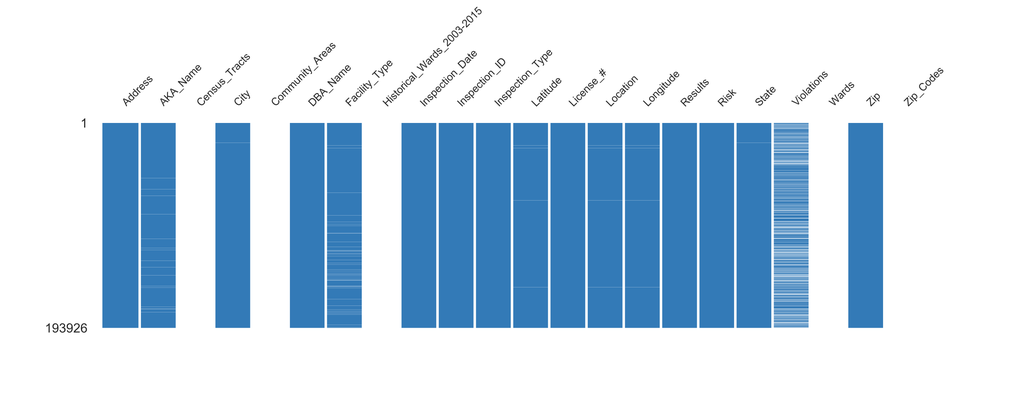

**Heatmap**

[figure not shown]

**Dendrogram**

[figure not shown]

# Sample

## First rows

|  | Address | AKA_Name | Census_Tracts | City | Community_Areas | DBA_Name | Facility_Type | Historical_Wards_2003-2015 | Inspection_Date | Inspection_ID | Inspection_Type | Latitude | License_# | Location | Longitude | Results | Risk | State | Violations | Wards | Zip | Zip_Codes |
| --- | --- | --- | --- | --- | --- | --- | --- | --- | --- | --- | --- | --- | --- | --- | --- | --- | --- | --- | --- | --- | --- | --- |
| 0 | 5752-5754 S PULASKI RD | THE LITTLE SCHOLARS CLUB | NaN | CHICAGO | NaN | THE LITTLE SCHOLARS CLUB | Daycare Combo 1586 | NaN | 10/04/2019 | 2315363 | License | 41.787989 | 2216135.0 | (-87.72316081027732, 41.78798915982268) | -87.723161 | Pass | Risk 1 (High) | IL | 47. FOOD & NON-FOOD CONTACT SURFACES CLEANABLE, PROPERLY DESIGNED, CONSTRUCTED & USED - Comments: FOUND THE WASH BOWLS (IN THE TOILET ROOMS) AND HAND SINK (IN THE CLASSROOM) IN NEED OF RECAULKING. INS… | NaN | 60629.0 | NaN |
| 1 | 1101 W WAVELAND AVE | KITCHFIX (PRESS BOX ANNEX) | NaN | CHICAGO | NaN | KITCHFIX | Restaurant | NaN | 10/04/2019 | 2315362 | Canvass | 41.948894 | 2522290.0 | (-87.65681760203104, 41.948894492280026) | -87.656818 | No Entry | Risk 1 (High) | IL | NaN | NaN | 60613.0 | NaN |
| 2 | 5836-5838 W CHICAGO AVE | KIDDIE KORRAL ACADEMY | NaN | CHICAGO | NaN | KIDDIE KORRAL ACADEMY | Children's Services Facility | NaN | 10/04/2019 | 2315379 | License | 41.894872 | 2215939.0 | (-87.77179591291225, 41.894872435106244) | -87.771796 | Pass | Risk 1 (High) | IL | NaN | NaN | 60651.0 | NaN |
| 3 | 4140 W BELMONT AVE | WENDY'S | NaN | CHICAGO | NaN | WENDY'S PROPERTIES, LLC | Restaurant | NaN | 10/04/2019 | 2315353 | Canvass Re-Inspection | 41.939152 | 2405954.0 | (-87.73125116042982, 41.93915237354105) | -87.731251 | Pass | Risk 1 (High) | IL | NaN | NaN | 60641.0 | NaN |
| 4 | 8233-8237 S PULASKI RD | THE LEARNING TREE ll | NaN | CHICAGO | NaN | THE LEARNING TREE ll | Children's Services Facility | NaN | 10/04/2019 | 2315401 | License | 41.742993 | 2215972.0 | (-87.72155821260196, 41.74299303153854) | -87.721558 | Fail | Risk 1 (High) | IL | 1. PERSON IN CHARGE PRESENT, DEMONSTRATES KNOWLEDGE, AND PERFORMS DUTIES - Comments: OBSERVED NO PERSON IN CHARGE WITH VALID CHICAGO FOOD SANITATION CERTIFICATE. INSTRUCTED MANAGER TO DESIGNATE PERSON… | NaN | 60652.0 | NaN |
| 5 | 316 W JACKSON BLVD | SHAKE SHACK | NaN | CHICAGO | NaN | SHAKE SHACK | Restaurant | NaN | 10/03/2019 | 2315348 | License Re-Inspection | 41.878207 | 2659344.0 | (-87.63572044703741, 41.87820739827345) | -87.635720 | Pass | Risk 3 (Low) | IL | NaN | NaN | 60606.0 | NaN |
| 6 | 3932 N BROADWAY | WINDY CITY GYROS | NaN | CHICAGO | NaN | WINDY CITY GYROS | Restaurant | NaN | 10/03/2019 | 2315309 | Canvass Re-Inspection | 41.953716 | 71095.0 | (-87.65014628741659, 41.95371591865941) | -87.650146 | Fail | Risk 1 (High) | IL | 5. PROCEDURES FOR RESPONDING TO VOMITING AND DIARRHEAL EVENTS - Comments: MUST PROVIDE ALL EQUIPMENT REQUIRED FOR THE WRITTEN VOMIT AND DIARRHEA CLEANING PROCEDURE ON SITE. PRIORITY FOUNDATION VIOLATI… | NaN | 60613.0 | NaN |
| 7 | 5255-5259 N CLARK ST | REZA'S RESTAURANT | NaN | CHICAGO | NaN | REZA'S ANDERSONVILLE | Restaurant | NaN | 10/03/2019 | 2315343 | Complaint Re-Inspection | 41.977843 | 2245694.0 | (-87.66820740032976, 41.97784289507301) | -87.668207 | Pass | Risk 1 (High) | IL | 36. THERMOMETERS PROVIDED & ACCURATE - Comments: OBSERVED COOLER/COLD HOLD UNIT IN KITCHEN NEAR REAR EXIT DOOR NEEDS THERMOMETER. INSTALL AND MAINTAIN. \| 47. FOOD & NON-FOOD CONTACT SURFACES CLEANABL… | NaN | 60640.0 | NaN |
| 8 | 1061 W ARGYLE ST | DOUBLE HAPPINESS | NaN | CHICAGO | NaN | DOUBLE HAPPINESS ENTERPRISES, INC. | Restaurant | NaN | 10/03/2019 | 2315320 | Complaint Re-Inspection | 41.973168 | 27480.0 | (-87.65736357565746, 41.97316839903074) | -87.657364 | Pass w/ Conditions | Risk 1 (High) | IL | 5. PROCEDURES FOR RESPONDING TO VOMITING AND DIARRHEAL EVENTS - Comments: OBSERVED PROCEDURE ON SITE BUT NO CLEAN UP KIT. INSTRUCTED OWNER TO OBTAIN CLEAN UP KIT AND MAINTAIN. PRIORITY FOUNDATION VIOL… | NaN | 60640.0 | NaN |
| 9 | 3519 N CLARK ST | KILWINS ICE CREAM AND CHOCOLATE | NaN | CHICAGO | NaN | KILWINS ICE CREAM AND CHOCOLATE | NaN | NaN | 10/03/2019 | 2315299 | License | 41.946281 | 2694404.0 | (-87.65560312808297, 41.94628081101039) | -87.655603 | Not Ready | All | IL | NaN | NaN | 60657.0 | NaN |

## Last rows

|  | Address | AKA_Name | Census_Tracts | City | Community_Areas | DBA_Name | Facility_Type | Historical_Wards_2003-2015 | Inspection_Date | Inspection_ID | Inspection_Type | Latitude | License_# | Location | Longitude | Results | Risk | State | Violations | Wards | Zip | Zip_Codes |
| --- | --- | --- | --- | --- | --- | --- | --- | --- | --- | --- | --- | --- | --- | --- | --- | --- | --- | --- | --- | --- | --- | --- |
| 193916 | 2010 N CENTRAL PARK AVE BLDG | FUNSTON ELEMENTARY SCH. MAIN BUILDING | NaN | CHICAGO | NaN | FUNSTON ELEMENTARY SCHOOL | School | NaN | 01/05/2010 | 134237 | Canvass | 41.917621 | 2112648.0 | (-87.71692852023781, 41.91762127382847) | -87.716929 | Pass | Risk 1 (High) | IL | 32. FOOD AND NON-FOOD CONTACT SURFACES PROPERLY DESIGNED, CONSTRUCTED AND MAINTAINED - Comments: All food and non-food contact equipment and utensils shall be smooth, easily cleanable, and durable, an… | NaN | 60647.0 | NaN |
| 193917 | 411 W 31ST ST | MAXWELL STREET DEPOT INC. | NaN | CHICAGO | NaN | MAXWELL STREET DEPOT INC. | Restaurant | NaN | 01/05/2010 | 118297 | Complaint | 41.838060 | 18135.0 | (-87.63665958710676, 41.838059998694526) | -87.636660 | Fail | Risk 2 (Medium) | IL | 18. NO EVIDENCE OF RODENT OR INSECT OUTER OPENINGS PROTECTED/RODENT PROOFED, A WRITTEN LOG SHALL BE MAINTAINED AVAILABLE TO THE INSPECTORS - Comments: All necessary control measures shall be used to e… | NaN | 60616.0 | NaN |
| 193918 | 1550 N KINGSBURY ST | KIKKA- KINGSBURY | NaN | CHICAGO | NaN | KIKKA- KINGSBURY | Restaurant | NaN | 01/05/2010 | 58226 | Canvass | 41.909399 | 1968898.0 | (-87.65305069789407, 41.90939878780941) | -87.653051 | Pass | Risk 1 (High) | IL | 34. FLOORS: CONSTRUCTED PER CODE, CLEANED, GOOD REPAIR, COVING INSTALLED, DUST-LESS CLEANING METHODS USED - Comments: The floors shall be constructed per code, be smooth and easily cleaned, and be kep… | NaN | 60642.0 | NaN |
| 193919 | 6 E CHESTNUT ST | TEMPO CAFE | NaN | CHICAGO | NaN | TEMPO CAFE | Restaurant | NaN | 01/04/2010 | 104236 | Canvass | 41.898431 | 80916.0 | (-87.6280091630558, 41.89843137207629) | -87.628009 | Fail | Risk 1 (High) | IL | 18. NO EVIDENCE OF RODENT OR INSECT OUTER OPENINGS PROTECTED/RODENT PROOFED, A WRITTEN LOG SHALL BE MAINTAINED AVAILABLE TO THE INSPECTORS - Comments: All necessary control measures shall be used to e… | NaN | 60611.0 | NaN |
| 193920 | 1834 W MONTROSE AVE | TROQUET | NaN | CHICAGO | NaN | WOLCOTT'S | Restaurant | NaN | 01/04/2010 | 67733 | License Re-Inspection | 41.961606 | 1992040.0 | (-87.67596676683779, 41.961605669949854) | -87.675967 | Pass | Risk 1 (High) | IL | NaN | NaN | 60613.0 | NaN |
| 193921 | 5645 W BELMONT AVE | mr.daniel's | NaN | CHICAGO | NaN | mr.daniel's | Restaurant | NaN | 01/04/2010 | 70269 | License Re-Inspection | 41.938443 | 1899292.0 | (-87.76831838068422, 41.93844282365204) | -87.768318 | Pass | Risk 1 (High) | IL | NaN | NaN | 60634.0 | NaN |
| 193922 | 8750 W BRYN WAWR AVE | MICHAEL'S ON MAIN CAFE | NaN | CHICAGO | NaN | MICHAEL'S ON MAIN CAFE | Restaurant | NaN | 01/04/2010 | 67738 | License | NaN | 2008948.0 | NaN | NaN | Fail | Risk 1 (High) | IL | 18. NO EVIDENCE OF RODENT OR INSECT OUTER OPENINGS PROTECTED/RODENT PROOFED, A WRITTEN LOG SHALL BE MAINTAINED AVAILABLE TO THE INSPECTORS - Comments: must provide pest control log book. \| 32. FOOD A… | NaN | 60631.0 | NaN |
| 193923 | 608 W BARRY AVE | Cafe 608 | NaN | CHICAGO | NaN | Cafe 608 | Restaurant | NaN | 01/04/2010 | 52234 | License Re-Inspection | 41.938007 | 2013328.0 | (-87.6447545707008, 41.938006880423615) | -87.644755 | Pass | Risk 1 (High) | IL | NaN | NaN | 60657.0 | NaN |
| 193924 | 100 W RANDOLPH ST | DUNKIN DONUTS/BASKIN-ROBBINS | NaN | CHICAGO | NaN | DUNKIN DONUTS/BASKIN-ROBBINS | Restaurant | NaN | 01/04/2010 | 67757 | Tag Removal | 41.884586 | 1380279.0 | (-87.63101044588599, 41.88458626715456) | -87.631010 | Pass | Risk 2 (Medium) | IL | NaN | NaN | 60601.0 | NaN |
| 193925 | 1834 W MONTROSE AVE | TROQUET | NaN | CHICAGO | NaN | WOLCOTT'S | Restaurant | NaN | 01/04/2010 | 67732 | License Re-Inspection | 41.961606 | 1992039.0 | (-87.67596676683779, 41.961605669949854) | -87.675967 | Pass | Risk 1 (High) | IL | NaN | NaN | 60613.0 | NaN |